# Final Project Summary

Bridget Lang

2024-11-16

*Disclaimer: This project is being conducted in support of Dr. Rob Wells, Associate Professor at the Phillip Merril College of Journalism, University of Maryland. Some verbiage in this summary is drawn directly from provided documentation about the project.*

# Welcome to my final project!

## Overview

This project will perform a basic narrative and topic analysis of the journalism of **Raymond Moley**, a prominent columnist who advocated a centrist conservative political vision from 1937 through 1967 in his books, weekly Newsweek column and syndicated newspaper column.

The goal of this project is to **measure patterns in wording, verbiage, themes, and sentiment** of Raymond Moley’s poltitical reporting over time. This research will support a larger effort in analyzing the **influence of journalism and polticial activism on American elections, voting, and democracy at large**.

I am focusing on the time period of Moley’s work from **1937-1952**, with an estimated **180 articles** to be analyzed.

## Libraries Used

Some of these libraries are used only in this webpage, but this is all libraries used in the analysis done so far.

```r
library(tidyverse)
library(pdftools)
library(dplyr)
library(rio)
library(tidytext)
library(quanteda)
library(knitr)
```

## Data Sample

This is the index of the all articles we currently have for this era, ranging from 1942-1956.

Article Index

| X | index | filename | date | year | month | day |
| --- | --- | --- | --- | --- | --- | --- |
| 1 | 1 | Moley_newsweek_1942-09-28_20_13.txt | 1942-09-28 | 1942 | 9 | 28 |
| 2 | 2 | Moley_newsweek_1942-10-19_20_16.txt | 1942-10-19 | 1942 | 10 | 19 |
| 3 | 3 | Moley_newsweek_1942-11-16_20_20.txt | 1942-11-16 | 1942 | 11 | 16 |
| 4 | 4 | Moley_newsweek_1942-12-07_20_23.txt | 1942-12-07 | 1942 | 12 | 7 |
| 5 | 5 | Moley_newsweek_1956-08-13_48_7.txt | 1956-08-13 | 1956 | 8 | 13 |
| 6 | 6 | Moley_newsweek_1956-09-10_48_11.txt | 1956-09-10 | 1956 | 9 | 10 |
| 7 | 7 | Moley_newsweek_1956-10-22_48_17.txt | 1956-10-22 | 1956 | 10 | 22 |
| 8 | 8 | Moley_newsweek_1956-11-05_48_19.txt | 1956-11-05 | 1956 | 11 | 5 |
| 9 | 9 | Moley_newsweek_1956-12-10_48_24.txt | 1956-12-10 | 1956 | 12 | 10 |
| 10 | 10 | perspective_1948-07-26_newsweek.txt | 1948-07-26 | 1948 | 7 | 26 |
| 11 | 11 | perspective_1948-08-09_sim_newsweek-us.txt | 1948-08-09 | 1948 | 8 | 9 |
| 12 | 12 | perspective_1948-09-06_sim_newsweek-us.txt | 1948-09-06 | 1948 | 9 | 6 |
| 13 | 13 | perspective_1948-10-18_sim_newsweek-us.txt | 1948-10-18 | 1948 | 10 | 18 |
| 14 | 14 | perspective_1948-11-15_sim_newsweek-us.txt | 1948-11-15 | 1948 | 11 | 15 |
| 15 | 15 | Perspective_1948-12-06_sim_newsweek-us.txt | 1948-12-06 | 1948 | 12 | 6 |

Text Sample

| X | sentence | date | year | month | day | filename |
| --- | --- | --- | --- | --- | --- | --- |
| 1 | NEWSWEEK Persp Registered The Cargo Plane by RAYMOND Loos ANGELES The decision | 1942-09-28 | 1942 | 9 | 28 | Moley_newsweek_1942-09-28_20_13.txt |
| 2 | of Donald Nelson to authorize Henry J. Kaiser to build three giant | 1942-09-28 | 1942 | 9 | 28 | Moley_newsweek_1942-09-28_20_13.txt |
| 3 | cargo planes in collaboration with Howard Hughes seems to make a good | 1942-09-28 | 1942 | 9 | 28 | Moley_newsweek_1942-09-28_20_13.txt |
| 4 | deal of sense. The interest aroused by this news and by the | 1942-09-28 | 1942 | 9 | 28 | Moley_newsweek_1942-09-28_20_13.txt |
| 5 | long and informative discussions that preceded it has done a great deal | 1942-09-28 | 1942 | 9 | 28 | Moley_newsweek_1942-09-28_20_13.txt |
| 6 | to make people appreciate the value of large cargo-flying ships. The experi- | 1942-09-28 | 1942 | 9 | 28 | Moley_newsweek_1942-09-28_20_13.txt |
| 7 | mental work now authorized will teach us all much that will be | 1942-09-28 | 1942 | 9 | 28 | Moley_newsweek_1942-09-28_20_13.txt |
| 8 | useful in the war effort and in transportation after the war. It | 1942-09-28 | 1942 | 9 | 28 | Moley_newsweek_1942-09-28_20_13.txt |
| 9 | is obvious that when an entirely new design is contemplated it takes | 1942-09-28 | 1942 | 9 | 28 | Moley_newsweek_1942-09-28_20_13.txt |
| 10 | time to produce even experimental models. It is estimated by Mr. Kaiser | 1942-09-28 | 1942 | 9 | 28 | Moley_newsweek_1942-09-28_20_13.txt |

## Columns and Rows

```
## The number of rows is 576
```

```
## The number of columns is 7
```

## Distribution of Data Over Time

For the purpose of this assignment I am making a chart that shows the number of articles by year but it is  
1. Very ugly  
2. Not very useful given that there are only 15 articles from 3 years.

```
##   year n
## 1 1942 4
## 2 1948 6
## 3 1956 5
```

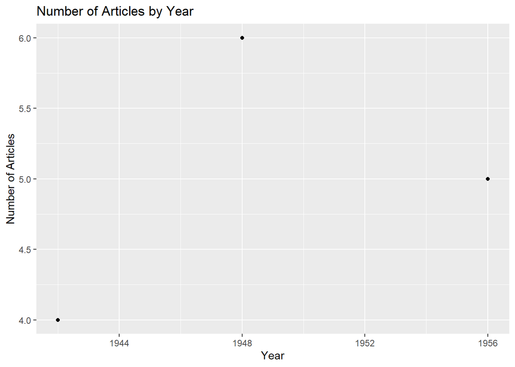